# Homework 4

Spencer Baumruk

10/28/2020

## Page 147, Problem 3

### Part (a)

```r
latour <- read.delim("D:/Box/Classes/00_2020 Fall/ST 452/HW 4/Latour.txt")
m1 <- lm(data=latour, Quality ~ EndofHarvest + Rain + Rain*EndofHarvest)
summary(m1)
```

```
##
## Call:
## lm(formula = Quality ~ EndofHarvest + Rain + Rain * EndofHarvest,
##     data = latour)
##
## Residuals:
##     Min      1Q  Median      3Q     Max
## -1.6833 -0.5703  0.1265  0.4385  1.6354
##
## Coefficients:
##                   Estimate Std. Error t value Pr(>|t|)
## (Intercept)        5.16122    0.68917   7.489 3.95e-09 ***
## EndofHarvest      -0.03145    0.01760  -1.787   0.0816 .
## Rain               1.78670    1.31740   1.356   0.1826
## EndofHarvest:Rain -0.08314    0.03160  -2.631   0.0120 *
## ---
## Signif. codes:  0 '***' 0.001 '**' 0.01 '*' 0.05 '.' 0.1 ' ' 1
##
## Residual standard error: 0.7578 on 40 degrees of freedom
## Multiple R-squared:  0.6848, Adjusted R-squared:  0.6612
## F-statistic: 28.97 on 3 and 40 DF,  p-value: 4.017e-10
```

We can see that the interaction term has a t value of -2.631 on 40 degrees of freedom, leading to a p-value of 0.012. To determine whether model with the interaction term is significant compared to the restricted model, we can do an f-test.

```r
m2 <- update(m1, ~.-Rain:EndofHarvest)
anova(m2,m1)
```

```
## Analysis of Variance Table
##
## Model 1: Quality ~ EndofHarvest + Rain
## Model 2: Quality ~ EndofHarvest + Rain + Rain * EndofHarvest
##   Res.Df    RSS Df Sum of Sq      F  Pr(>F)
## 1     41 26.945
## 2     40 22.971  1    3.9749 6.9218 0.01203 *
## ---
## Signif. codes:  0 '***' 0.001 '**' 0.01 '*' 0.05 '.' 0.1 ' ' 1
```

### Part (b)

Based on our coefficients in m1, each day following the end of harvest during a year without unwanted rain decreases the quality by 0.03145, meaning it would take about 31.8 days for quality to decrease by one point. During a year with unwanted rain at harvest, each day following the end of harvest decreases the quality by 0.03145+0.08314=0.11459, meaning it would take about 8.7 days for quality to decrease by one point.

## College Football

### Part (a): Overall Model

```r
cfb <- read_excel("cfb.xlsx")
```

```r
cfb <- cfb %>% mutate(winrate = win/Games)
cfb <- select(cfb,winrate,Off.Rank,Def.Rank,'First Down Rank','4th Down Rank', 'Penalty Rank', 'Sack Rank', 'Turnover Rank')
m1 <- lm(data=cfb, winrate~.)
summary(m1)
```

```
##
## Call:
## lm(formula = winrate ~ ., data = cfb)
##
## Residuals:
##       Min        1Q    Median        3Q       Max
## -0.272998 -0.056886  0.003376  0.073394  0.208201
##
## Coefficients:
##                     Estimate Std. Error t value Pr(>|t|)
## (Intercept)        1.0088611  0.0318419  31.683  < 2e-16 ***
## Off.Rank          -0.0002446  0.0005624  -0.435  0.66435
## Def.Rank          -0.0019902  0.0003211  -6.198 8.04e-09 ***
## `First Down Rank` -0.0024360  0.0005884  -4.140 6.42e-05 ***
## `4th Down Rank`   -0.0004462  0.0002602  -1.715  0.08889 .
## `Penalty Rank`    -0.0001739  0.0002395  -0.726  0.46920
## `Sack Rank`       -0.0010508  0.0002923  -3.594  0.00047 ***
## `Turnover Rank`   -0.0011481  0.0002599  -4.418 2.17e-05 ***
## ---
## Signif. codes:  0 '***' 0.001 '**' 0.01 '*' 0.05 '.' 0.1 ' ' 1
##
## Residual standard error: 0.1001 on 122 degrees of freedom
## Multiple R-squared:  0.7991, Adjusted R-squared:  0.7875
## F-statistic: 69.31 on 7 and 122 DF,  p-value: < 2.2e-16
```

Immediately, we can see that we have four significant variables at the .05 significant level, those being Def.Rank, First Down Rank, Sack Rank, and Turnover Rank. Our model’s F-statistic is high, being 69.31 with df=(7,122), giving us an extremely small p-value. The overall model fit is quite good.

### Part (b): Multicollinearity

We can expect that we may have some issues with multicollinearity, especially when it comes to the relationship between offensive rank and first down rank, as well as the relationship between defensive rank, sack rank, and turnover rank.

Let’s check our pairs plot.

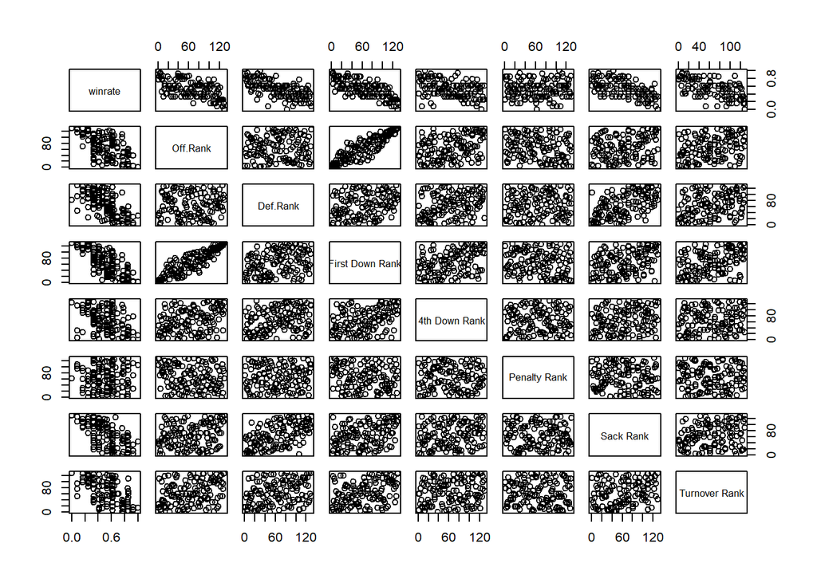

```r
pairs(cfb)
```

We can see some closely correlated variables from the plot, especially between offensive rank and first down rank. Let’s check the variance inflation factors for each predictor.

```r
vif(m1)
```

```
##          Off.Rank          Def.Rank `First Down Rank`   `4th Down Rank`
##          5.785168          1.886372          6.311382          1.235019
##    `Penalty Rank`       `Sack Rank`   `Turnover Rank`
##          1.048723          1.538017          1.233693
```

We can see fairly good VIF’s for most predictors except for offensive rank and first down rank. This confirms our suspicion based on the pairwise relationship chart that there is a high degree of multicollinearity between offensive rank and first down rank. Let’s update our model by removing first down rank.

```r
m2 <- update(m1, ~.-`First Down Rank`)
vif(m2)
```

```
##        Off.Rank        Def.Rank `4th Down Rank`  `Penalty Rank`     `Sack Rank`
##        1.338604        1.632734        1.230673        1.047616        1.520526
## `Turnover Rank`
##        1.220912
```

Much better. Let’s now check our model to evaluate its adequacy.

```r
summary(m2)
```

```
##
## Call:
## lm(formula = winrate ~ Off.Rank + Def.Rank + `4th Down Rank` +
##     `Penalty Rank` + `Sack Rank` + `Turnover Rank`, data = cfb)
##
## Residuals:
##      Min       1Q   Median       3Q      Max
## -0.29663 -0.05474  0.01061  0.07453  0.22584
##
## Coefficients:
##                   Estimate Std. Error t value Pr(>|t|)
## (Intercept)      1.0375540  0.0330551  31.389  < 2e-16 ***
## Off.Rank        -0.0022860  0.0002877  -7.945 1.05e-12 ***
## Def.Rank        -0.0024776  0.0003177  -7.798 2.29e-12 ***
## `4th Down Rank` -0.0005102  0.0002763  -1.847 0.067206 .
## `Penalty Rank`  -0.0002061  0.0002546  -0.810 0.419755
## `Sack Rank`     -0.0011799  0.0003092  -3.816 0.000213 ***
## `Turnover Rank` -0.0012576  0.0002750  -4.574 1.15e-05 ***
## ---
## Signif. codes:  0 '***' 0.001 '**' 0.01 '*' 0.05 '.' 0.1 ' ' 1
##
## Residual standard error: 0.1064 on 123 degrees of freedom
## Multiple R-squared:  0.7708, Adjusted R-squared:  0.7596
## F-statistic: 68.95 on 6 and 123 DF,  p-value: < 2.2e-16
```

Now we see that offensive rank is significant, as expected. We now have a model where there is a minimal amount of multicollinearity, with an F-statistic of 68.95 and extremely low p-value, with four predictor variables identified as significant at the .05 level.

### Part (c)

As suggested above, offensive rank had information built into it with first down rank. By eliminating first down rank from our model, we can get a better understanding of the marginal effect of offensive rank on the win rate by looking at the estimator coefficient in our updated, restricted model.